# Premier League Football Analysis

**Group:** Cody Li, Shreyas Pant

```python
import pandas as pd
import numpy as np
import matplotlib.pyplot as plt
import seaborn as sns
```

# Getting the Data

The first step in our data exploration process is to get the necessary data. For this tutorial, we will be using data on the 2018-2019 Premier League Football season provided by datahub.io. You can download the data yourself at by clicking [HERE](https://datahub.io/sports-data/english-premier-league#resource-season-1819).

Fortunately, the data is provided in CSV format which eliminates the need to scrape the data inside HTML tags. We can start working with the data simply by using Pandas' built in .read_csv() function which will return a Pandas.DataFrame for us to use.

```python
# Provided by https://datahub.io/sports-data/english-premier-league#resource-season-1819

raw_data = pd.read_csv('https://pkgstore.datahub.io/sports-data/english-premier-league/season-1819_csv/data/916634f7ec37dd45c86159bc723eb340/season-1819_csv.csv')
raw_data.head()
```

|  | Div | Date | HomeTeam | AwayTeam | FTHG | FTAG | FTR | HTHG | HTAG | HTR | ... | BbAv<2.5 | BbAH | BbAHh | BbMxAHH | BbAvAHH | BbMxAHA | BbAvAHA | PSCH | PSCD | PSCA |
| --- | --- | --- | --- | --- | --- | --- | --- | --- | --- | --- | --- | --- | --- | --- | --- | --- | --- | --- | --- | --- | --- |
| 0 | E0 | 10/08/2018 | Man United | Leicester | 2 | 1 | H | 1 | 0 | H | ... | 1.79 | 17 | -0.75 | 1.75 | 1.70 | 2.29 | 2.21 | 1.55 | 4.07 | 7.69 |
| 1 | E0 | 11/08/2018 | Bournemouth | Cardiff | 2 | 0 | H | 1 | 0 | H | ... | 1.83 | 20 | -0.75 | 2.20 | 2.13 | 1.80 | 1.75 | 1.88 | 3.61 | 4.70 |
| 2 | E0 | 11/08/2018 | Fulham | Crystal Palace | 0 | 2 | A | 0 | 1 | A | ... | 1.87 | 22 | -0.25 | 2.18 | 2.11 | 1.81 | 1.77 | 2.62 | 3.38 | 2.90 |
| 3 | E0 | 11/08/2018 | Huddersfield | Chelsea | 0 | 3 | A | 0 | 2 | A | ... | 1.84 | 23 | 1.00 | 1.84 | 1.80 | 2.13 | 2.06 | 7.24 | 3.95 | 1.58 |
| 4 | E0 | 11/08/2018 | Newcastle | Tottenham | 1 | 2 | A | 1 | 2 | A | ... | 1.81 | 20 | 0.25 | 2.20 | 2.12 | 1.80 | 1.76 | 4.74 | 3.53 | 1.89 |

5 rows × 62 columns

## The Columns

For those unfamiliar with soccer/football statistics acronyms, here are some of the columns that we will be using and what each of them represent:

- FTHG --> Full Time Home Goals (how many goals the home team scored in 90 minutes)
- FTAG --> Full Time Away Goals (how many goals the away team scored in 90 minutes)
- FTR --> Full Time Result (who won, H is home, A is away, D is draw)
- HTHG --> Half Time Home Goals (how many goals the home team scored in 45 minutes)
- HTAG --> Half Time Away Goals (how many goals the away team scored in 45 minutes)
- HTR --> Half Time Result
- HS --> Home Shots
- AS --> Away Shots
- HST --> Home Shots on Target
- AST --> Away Shots on Target
- HF --> Home Fouls
- AF --> Away Fouls
- HC --> Home Crosses
- AC --> Away Crosses
- HY --> Home Yellow Cards
- AY --> Away Yellow Cards
- HR --> Home Red Cards
- AR --> Away Red Cards
- B365H --> Odds from Bet365 for a Home Victory
- B365D --> Odds from Bet365 for a Draw
- B365A --> Odds from Bet365 for an Away Victory

The remaining columns are represent betting odds from other betting platforms and other related statistics which serve little purpose for the sake of our data exploration. Additionally, the 'Div' column serves no purpose for this dataset as all entries belong in the same 'Div'.

## Cleaning and Preprocessing

Often times when we use datasets on the internet, the dataset may not be very usable and may require some cleaning and preprocessing to make it more readable and easier to use. There are multiple ways to clean and preprocess data, such as directly editing the data using some sort of text editor or fixing CSV data in Microsoft Excel/Google Sheets. While these methods are great for quickly fixing small errors in small datasets, they can become very time consuming in larger datasets with more errors.

For this tutorial, we will be importing the data into Pandas and doing the preprocessing using a DataFrame as the Pandas library provides a variety of simple and useful functions for cleaning and preprocessing data quickly and efficiently. More info on Pandas DataFrames and built in functions can be found at: https://pandas.pydata.org/docs/reference/api/pandas.DataFrame.html

Some of the problems we may encounter with these datasets include but are not limited to:

- Missing or incomplete data in some entries.
- Unintentional duplicates (columns, entries, etc)
- Extraneous rows/columns often encountered when web scraping.
- Incorrect data formatting (i.e. data/time data can can be hard to parse when not in proper format)
- Unnecessarily separation of data into multiple columns (i.e. separaing phone number into 3-4 columns when not needed)
- Qualitative data needs to be one-hot encoded for modeling

For our data, luckily, it is mostly usable, but one potential issue we ran into was that the dates in our 'Date' column were in European format (dd/mm/yyyy) and were not automatically parsed as a 'datetime' type by Pandas. This required us to convert the 'Date' column into a 'datetime' type using Pandas.to_datetime() specifying that the date started with the day first.

```python
df = raw_data.copy()

# Check output below to see that all entries have the same 'Div' value and therefore the column serves little purpose.
print(raw_data['Div'].unique())

# Removing the unnecessary columns for better readability
df[['Date', 'HomeTeam', 'AwayTeam', 'FTHG', 'FTAG', 'FTR', 'HTHG', 'HTAG', 'HTR', 'HS', 'AS', 'HST', 'AST', 'HF', 'AF', 'HC', 'AC', 'HY', 'AY', 'HR', 'AR', 'B365H', 'B365D', 'B365A']]
df.drop(['Div'], axis=1, inplace=True)

# Converting date column into datetime type with European date format
df['Date'] = pd.to_datetime(df['Date'], dayfirst=True)
df.sort_values(by=['Date'], ascending=False)
df.head(10)
```

```
['E0']
```

|  | Date | HomeTeam | AwayTeam | FTHG | FTAG | FTR | HTHG | HTAG | HTR | Referee | ... | BbAv<2.5 | BbAH | BbAHh | BbMxAHH | BbAvAHH | BbMxAHA | BbAvAHA | PSCH | PSCD | PSCA |
| --- | --- | --- | --- | --- | --- | --- | --- | --- | --- | --- | --- | --- | --- | --- | --- | --- | --- | --- | --- | --- | --- |
| 0 | 2018-08-10 | Man United | Leicester | 2 | 1 | H | 1 | 0 | H | A Marriner | ... | 1.79 | 17 | -0.75 | 1.75 | 1.70 | 2.29 | 2.21 | 1.55 | 4.07 | 7.69 |
| 1 | 2018-08-11 | Bournemouth | Cardiff | 2 | 0 | H | 1 | 0 | H | K Friend | ... | 1.83 | 20 | -0.75 | 2.20 | 2.13 | 1.80 | 1.75 | 1.88 | 3.61 | 4.70 |
| 2 | 2018-08-11 | Fulham | Crystal Palace | 0 | 2 | A | 0 | 1 | A | M Dean | ... | 1.87 | 22 | -0.25 | 2.18 | 2.11 | 1.81 | 1.77 | 2.62 | 3.38 | 2.90 |
| 3 | 2018-08-11 | Huddersfield | Chelsea | 0 | 3 | A | 0 | 2 | A | C Kavanagh | ... | 1.84 | 23 | 1.00 | 1.84 | 1.80 | 2.13 | 2.06 | 7.24 | 3.95 | 1.58 |
| 4 | 2018-08-11 | Newcastle | Tottenham | 1 | 2 | A | 1 | 2 | A | M Atkinson | ... | 1.81 | 20 | 0.25 | 2.20 | 2.12 | 1.80 | 1.76 | 4.74 | 3.53 | 1.89 |
| 5 | 2018-08-11 | Watford | Brighton | 2 | 0 | H | 1 | 0 | H | J Moss | ... | 1.59 | 22 | -0.25 | 2.07 | 2.01 | 1.90 | 1.86 | 2.58 | 3.08 | 3.22 |
| 6 | 2018-08-11 | Wolves | Everton | 2 | 2 | D | 1 | 1 | D | C Pawson | ... | 1.75 | 22 | -0.25 | 2.04 | 1.98 | 1.92 | 1.88 | 2.44 | 3.23 | 3.32 |
| 7 | 2018-08-12 | Arsenal | Man City | 0 | 2 | A | 0 | 1 | A | M Oliver | ... | 2.42 | 20 | 0.75 | 1.78 | 1.74 | 2.21 | 2.15 | 4.43 | 4.13 | 1.81 |
| 8 | 2018-08-12 | Liverpool | West Ham | 4 | 0 | H | 2 | 0 | H | A Taylor | ... | 2.72 | 21 | -1.75 | 1.95 | 1.90 | 2.06 | 1.97 | 1.25 | 6.95 | 12.00 |
| 9 | 2018-08-12 | Southampton | Burnley | 0 | 0 | D | 0 | 0 | D | G Scott | ... | 1.60 | 20 | -0.75 | 2.19 | 2.11 | 1.82 | 1.76 | 2.03 | 3.19 | 4.65 |

10 rows × 61 columns

## Finding the Winning and Losing Teams

For our dataset, notice how the winning and losing teams are not explicitly recorded in a column. We are, however, given the 'FTR' column which records the result whether that may be the home team won, or the away team won, or there was a draw. To make the data more readable and easier to use, we can use this info to create two new columns that explicityly record the winning and losing teams.

There are multiple approaches to adding the winning and losing team columns such as iterating throught each row using .iterrows(), using the apply() method with a lambda function, or using vectorized functions. While the first two are valid options and are more intuitive, for this tutorial, we will be using vectorized functions as the are more optimized and can be significantly faster than the previous two approaches. For more information on how to speed up operations using vectorized functions, check this article: https://plainenglish.io/blog/pandas-how-you-can-speed-up-50x-using-vectorized-operations

```python
%%timeit
# Vectorizied functions using numpy's where function to conditionally select the winning and losing teams based off 'FTR' column.
df['WinTeam'] = np.where(df['FTR'] == 'H', df['HomeTeam'], np.where(df['FTR'] == 'A', df['AwayTeam'], 'Draw'))
df['LoseTeam'] = np.where(df['FTR'] == 'A', df['HomeTeam'], np.where(df['FTR'] == 'H', df['AwayTeam'], 'Draw'))
df.head()
```

```
1.23 ms ± 71.2 µs per loop (mean ± std. dev. of 7 runs, 1000 loops each)
```

```python
%%timeit
# Using the .apply() method with lambda functions on the DataFrame to select the winning and losing teams.
df['WinTeam'] = df.apply(lambda row: row['HomeTeam'] if row['FTR'] == 'H' else (row['AwayTeam'] if row['FTR'] == 'A' else 'Draw'), axis=1)
df['LoseTeam'] = df.apply(lambda row: row['HomeTeam'] if row['FTR'] == 'A' else (row['AwayTeam'] if row['FTR'] == 'H' else 'Draw'), axis=1)
```

```
15.5 ms ± 140 µs per loop (mean ± std. dev. of 7 runs, 100 loops each)
```

Notice that the average runtime of the vectorized function is significantly faster than using apply. From a practicality standpoint, they're both in miliseconds right now so a normal person would not be able to really tell a difference. But datasets grow larger, the difference in execution time may grows increasingly apparent. (miliseconds vs minutes)

## Tallying Up Wins

Since our dataset has a 'Date' attribute, one of the things we can explore with our data is the wins for each team over time.

Since we want to get the number of wins per team over time, we need to count the number of wins for each team per date. To do this, we will use the .groupby() method to group on both teams and dates and counting the size of each group to get the number of wins. Of course, we can achieve a similar result using nested for loops iterating each combination of teams and dates and counting their wins, but using the .groupby() method will result in less code and making it easier to read.

Note that after the group by, we used the .reset_index() method to convert the GroupBySeries back to a normal DataFrame. This is because after the group by, both 'Date' and 'WinTeam' are combined to become the new index column, however we still need them for later so we will be converting it back to a normal DataFrame.

```python
# Get list of unique Teams for 'HomeTeam' and 'AwayTeam'
#home = df['HomeTeam'].unique()
away = df['AwayTeam'].unique()

# Flatten the resulting numpy arrays so that they can be converted into sets before being unioned to prevent duplicates
#home = set(home.flatten())
#away = set(away.flatten())
#teams = home.union(away)

# Group by dates and wins counting number of wins before converting back to normal DataFrame
dfg = df.groupby(['Date', 'WinTeam']).size().reset_index()

# Renaming new count column
dfg.rename({dfg.columns[2] : 'Wins'}, axis=1, inplace=True)

dfg.head(10)
```

|  | Date | WinTeam | Wins |
| --- | --- | --- | --- |
| 0 | 2018-08-10 | Man United | 1 |
| 1 | 2018-08-11 | Bournemouth | 1 |
| 2 | 2018-08-11 | Chelsea | 1 |
| 3 | 2018-08-11 | Crystal Palace | 1 |
| 4 | 2018-08-11 | Draw | 1 |
| 5 | 2018-08-11 | Tottenham | 1 |
| 6 | 2018-08-11 | Watford | 1 |
| 7 | 2018-08-12 | Draw | 1 |
| 8 | 2018-08-12 | Liverpool | 1 |
| 9 | 2018-08-12 | Man City | 1 |

Now that we have the wins per date per team, we want to tally the wins for each team by date. With the DataFrame in its current format, it is both hard to read and work with to tally up the wins. We can expand the table sideways using .pivot_table() method to turn the teams into columns.

Notice .pivot_table() also introduce NaN into our table. We need to replace all occurences of NaN with 0 so that the wins can be tallied up correctly. We should also drop the Draws as we want to count wins per team so it serves no purpose here.

```python
scores = dfg.copy()

# Spread out the teams into columns for better data representation and processing
scores = scores.pivot_table(index='Date', columns='WinTeam', values = 'Wins')

# Replace NaNs with 0s
scores.fillna(0.0, inplace=True)

# Drop the unnecessary Draw count
scores = scores.drop(['Draw'], axis=1)

scores.head()
```

| WinTeam Date | Arsenal | Bournemouth | Brighton | Burnley | Cardiff | Chelsea | Crystal Palace | Everton | Fulham | Huddersfield | Leicester | Liverpool | Man City | Man United | Newcastle | Southampton | Tottenham | Watford | West Ham | Wolves |
| --- | --- | --- | --- | --- | --- | --- | --- | --- | --- | --- | --- | --- | --- | --- | --- | --- | --- | --- | --- | --- |
| 2018-08-10 | 0.0 | 0.0 | 0.0 | 0.0 | 0.0 | 0.0 | 0.0 | 0.0 | 0.0 | 0.0 | 0.0 | 0.0 | 0.0 | 1.0 | 0.0 | 0.0 | 0.0 | 0.0 | 0.0 | 0.0 |
| 2018-08-11 | 0.0 | 1.0 | 0.0 | 0.0 | 0.0 | 1.0 | 1.0 | 0.0 | 0.0 | 0.0 | 0.0 | 0.0 | 0.0 | 0.0 | 0.0 | 0.0 | 1.0 | 1.0 | 0.0 | 0.0 |
| 2018-08-12 | 0.0 | 0.0 | 0.0 | 0.0 | 0.0 | 0.0 | 0.0 | 0.0 | 0.0 | 0.0 | 0.0 | 1.0 | 1.0 | 0.0 | 0.0 | 0.0 | 0.0 | 0.0 | 0.0 | 0.0 |
| 2018-08-18 | 0.0 | 1.0 | 0.0 | 0.0 | 0.0 | 1.0 | 0.0 | 1.0 | 0.0 | 0.0 | 1.0 | 0.0 | 0.0 | 0.0 | 0.0 | 0.0 | 1.0 | 0.0 | 0.0 | 0.0 |
| 2018-08-19 | 0.0 | 0.0 | 1.0 | 0.0 | 0.0 | 0.0 | 0.0 | 0.0 | 0.0 | 0.0 | 0.0 | 0.0 | 1.0 | 0.0 | 0.0 | 0.0 | 0.0 | 1.0 | 0.0 | 0.0 |

Now that we have properly expanded the table so that each row represents the number of wins (cells) for each team (columns) for that date (rows). We can cumulatively tally up the wins to get the total wins for each team up until that date. There are various ways to do this, for example, a bruteforce approach would be to create a new DataFrame and iterate through each date, filtering through the 'scores' DataFrame for all dates before less than or equal to it and sum them up.

However this approach is not very efficient, so for this tutorial, we will just iterate through each row and cumulatively add the sum up the previous row with the current row.

```python
tally = scores.copy()

# Get all the unique dates games were played on
dates = df['Date'].unique()

# Iterate through each date, adding the sum up to the previous date with the counts of the new date
for i in range(1, len(dates)):
  tally.iloc[i] = tally.iloc[i-1] + tally.iloc[i]

tally
```

| WinTeam Date | Arsenal | Bournemouth | Brighton | Burnley | Cardiff | Chelsea | Crystal Palace | Everton | Fulham | Huddersfield | Leicester | Liverpool | Man City | Man United | Newcastle | Southampton | Tottenham | Watford | West Ham | Wolves |
| --- | --- | --- | --- | --- | --- | --- | --- | --- | --- | --- | --- | --- | --- | --- | --- | --- | --- | --- | --- | --- |
| 2018-08-10 | 0.0 | 0.0 | 0.0 | 0.0 | 0.0 | 0.0 | 0.0 | 0.0 | 0.0 | 0.0 | 0.0 | 0.0 | 0.0 | 1.0 | 0.0 | 0.0 | 0.0 | 0.0 | 0.0 | 0.0 |
| 2018-08-11 | 0.0 | 1.0 | 0.0 | 0.0 | 0.0 | 1.0 | 1.0 | 0.0 | 0.0 | 0.0 | 0.0 | 0.0 | 0.0 | 1.0 | 0.0 | 0.0 | 1.0 | 1.0 | 0.0 | 0.0 |
| 2018-08-12 | 0.0 | 1.0 | 0.0 | 0.0 | 0.0 | 1.0 | 1.0 | 0.0 | 0.0 | 0.0 | 0.0 | 1.0 | 1.0 | 1.0 | 0.0 | 0.0 | 1.0 | 1.0 | 0.0 | 0.0 |
| 2018-08-18 | 0.0 | 2.0 | 0.0 | 0.0 | 0.0 | 2.0 | 1.0 | 1.0 | 0.0 | 0.0 | 1.0 | 1.0 | 1.0 | 1.0 | 0.0 | 0.0 | 2.0 | 1.0 | 0.0 | 0.0 |
| 2018-08-19 | 0.0 | 2.0 | 1.0 | 0.0 | 0.0 | 2.0 | 1.0 | 1.0 | 0.0 | 0.0 | 1.0 | 1.0 | 2.0 | 1.0 | 0.0 | 0.0 | 2.0 | 2.0 | 0.0 | 0.0 |
| ... | ... | ... | ... | ... | ... | ... | ... | ... | ... | ... | ... | ... | ... | ... | ... | ... | ... | ... | ... | ... |
| 2019-05-03 | 20.0 | 12.0 | 9.0 | 11.0 | 9.0 | 20.0 | 12.0 | 15.0 | 7.0 | 3.0 | 15.0 | 28.0 | 30.0 | 19.0 | 11.0 | 9.0 | 23.0 | 14.0 | 13.0 | 15.0 |
| 2019-05-04 | 20.0 | 13.0 | 9.0 | 11.0 | 9.0 | 20.0 | 13.0 | 15.0 | 7.0 | 3.0 | 15.0 | 29.0 | 30.0 | 19.0 | 11.0 | 9.0 | 23.0 | 14.0 | 14.0 | 16.0 |
| 2019-05-05 | 20.0 | 13.0 | 9.0 | 11.0 | 9.0 | 21.0 | 13.0 | 15.0 | 7.0 | 3.0 | 15.0 | 29.0 | 30.0 | 19.0 | 11.0 | 9.0 | 23.0 | 14.0 | 14.0 | 16.0 |
| 2019-05-06 | 20.0 | 13.0 | 9.0 | 11.0 | 9.0 | 21.0 | 13.0 | 15.0 | 7.0 | 3.0 | 15.0 | 29.0 | 31.0 | 19.0 | 11.0 | 9.0 | 23.0 | 14.0 | 14.0 | 16.0 |
| 2019-05-12 | 21.0 | 13.0 | 9.0 | 11.0 | 10.0 | 21.0 | 14.0 | 15.0 | 7.0 | 3.0 | 15.0 | 30.0 | 32.0 | 19.0 | 12.0 | 9.0 | 23.0 | 14.0 | 15.0 | 16.0 |

108 rows × 20 columns

Using matplotlib library we can plot the data calculated above over time as a line graph.

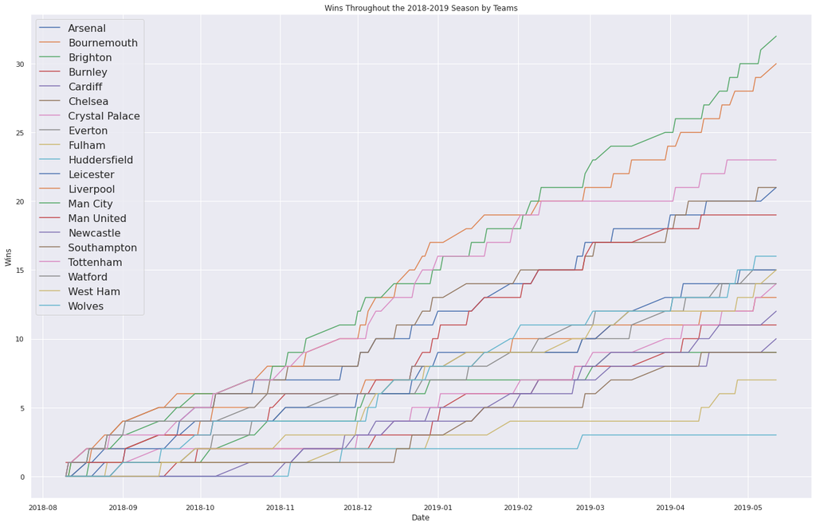

```python
plt.figure(figsize = (22, 14))
for team in tally.columns:
  #plt.step(x=dates, y=tally[team], label=team)
  plt.plot(dates, tally[team], label=team)

plt.legend(prop={'size': 16})
plt.title('Wins Throughout the 2018-2019 Season by Teams')
plt.xlabel('Date')
plt.ylabel('Wins')
plt.show()
```

From this graph, we can see that the top five teams with most wins are Man City, Liverpool, Tottenham, Chelsea, and Arsenal. We can also see that the lines for the first two teams, Man City and Liverpool, are very close to the y=x line indicating that these two teams have very high win rates.

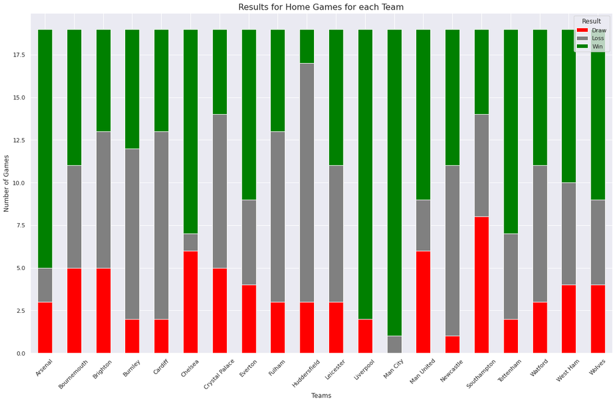

```python
results = df.copy()[['Date', 'HomeTeam', 'AwayTeam', 'FTR']]
results.rename({results.columns[3] : 'Result'}, axis=1, inplace=True)
resmap = {'H' : 'Win', 'A' : 'Loss', 'D' : 'Draw'}
results['Result'] = results.apply(lambda row: resmap[row['Result']], axis=1)

dfg = results.groupby(['HomeTeam', 'Result']).size().reset_index()
dfg.rename({dfg.columns[2] : 'Count'}, axis=1, inplace=True)

results = dfg.pivot_table(index='HomeTeam', columns='Result', values='Count')

sns.set(style='darkgrid')
results.plot(kind='bar', stacked=True, color=['red', 'gray', 'green'], figsize=(20,12))
plt.title('Results for Home Games for each Team', fontsize=16)
plt.ylabel('Number of Games')
plt.xlabel('Teams')
plt.xticks(rotation=45)
```